# Gompertz Model Fitting: Reverse-Engineering the Hendrickson Parameters from the Raskind et al. (2013) Trial Data

# Background

The Hendrickson et al. (2020) simulation uses a modified Gompertz function to model the expected trajectory of each response factor (BR, ER, TR) over time. The parameters for this function were extracted from the Raskind et al. (2013) parallel-group RCT of prazosin for PTSD in active-duty soldiers (Am J Psychiatry 170:1003-1010).

This document reverse-engineers the data from the published figures and tables, fits the modified Gompertz model, and compares the fitted parameters with those used in the simulation.

# Summary of Raskind et al. (2013)

**Trial design:** 15-week double-blind RCT, N=67 (32 prazosin, 35 placebo), with 6-week titration period. Assessments at baseline, weeks 7, 11, and 15.

**The biomarker:** Standing systolic blood pressure (2 min after standing). Table 3 shows baseline standing systolic BP: prazosin group mean=125, placebo group mean=121 mmHg. Blood pressure did not significantly differ over time or between groups (p=0.61).

**The outcome:** CAPS total score. Baseline: prazosin 77.3, placebo 85.7. Week 15: prazosin 52.4, placebo 71.9. Difference in change from baseline: 11.3 points (p=0.02).

**Where the Hendrickson simulation parameters came from:**

**The biomarker-treatment interaction finding:** This paper does not test it directly. Hendrickson et al. (2020) cites a separate post-hoc analysis (Raskind et al. 2016, Biol Psychiatry 80:736-42) that found ‘higher pretreatment blood pressure is associated with greater PTSD symptom reduction in soldiers treated with prazosin.’ That finding motivated the N-of-1 trial design to validate the biomarker prospectively.

**Prazosin pharmacokinetics:** The paper notes prazosin has a ‘short duration of action (6 to 10 hours),’ which is why twice-daily dosing was used. This maps to a carryover half-life of roughly 3-5 hours (0.02-0.03 weeks) – much shorter than even the Hendrickson publication’s 0.1 weeks. At these true pharmacokinetic half-lives, the carryover residual between weekly assessments is negligible.

# The Modified Gompertz Function

The function used in pmsimstats is:

$$f(t) = \text{max} \cdot e^{-\text{disp}
\cdot e^{-\text{rate} \cdot t}}$$

with an offset-rescaling to ensure $f(0) = 0$ and $f(\infty) = \text{max}$:

```r
modgompertz <- function(t, maxr, disp, rate) {
  y <- maxr * exp(-disp * exp(-rate * t))
  vert_offset <- maxr * exp(-disp * exp(-rate * 0))
  y <- y - vert_offset
  y <- y * (maxr / (maxr - vert_offset))
  y
}
```

# Extracting Data from Raskind et al. (2013)

## CAPS Total Score Trajectories

From Table 3 and Figure 1D of Raskind et al. (2013):

```r
# Assessment timepoints (weeks)
weeks <- c(0, 7, 11, 15)

# CAPS total scores (adjusted means from Table 3)
caps_prazosin <- c(77.3, NA, NA, 52.4)
caps_placebo  <- c(85.7, NA, NA, 71.9)

# Interpolate weeks 7 and 11 from Figure 1D
# (read approximately from the plotted curves)
caps_prazosin <- c(77.3, 60, 54, 52.4)
caps_placebo  <- c(85.7, 76, 74, 71.9)

trial_data <- data.table(
  week = rep(weeks, 2),
  caps = c(caps_prazosin, caps_placebo),
  group = rep(c("Prazosin", "Placebo"), each = 4)
)

# Compute change from baseline (improvement is positive)
trial_data[, baseline := caps[1], by = group]
trial_data[, improvement := baseline - caps]
```

## Visualize the Raw Trajectories

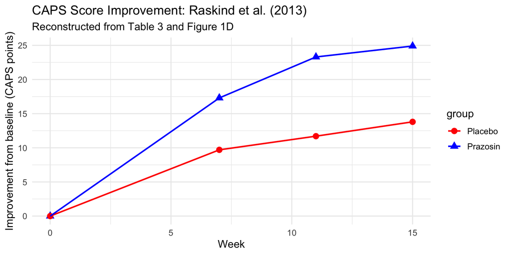

```r
ggplot(trial_data, aes(x = week, y = improvement,
                       color = group, shape = group)) +
  geom_point(size = 3) +
  geom_line(linewidth = 0.8) +
  labs(x = "Week", y = "Improvement from baseline (CAPS points)",
       title = "CAPS Score Improvement: Raskind et al. (2013)",
       subtitle = "Reconstructed from Table 3 and Figure 1D") +
  scale_color_manual(values = c("Placebo" = "red",
                                "Prazosin" = "blue")) +
  theme_minimal(base_size = 12) +
  theme(legend.position = "right")
```

## Decompose into Three Factors

Following Hendrickson et al. (2020):

- **TV + ER** (combined): the placebo group trajectory. Since placebo participants receive no drug, their improvement is entirely non-specific (time-variant + expectancy).
- **BR**: the difference between prazosin and placebo trajectories. This isolates the drug-specific effect.

```r
# Separate by group
praz <- trial_data[group == "Prazosin"]
plac <- trial_data[group == "Placebo"]

# BR = prazosin improvement - placebo improvement
br_improvement <- praz$improvement - plac$improvement

# TV+ER = placebo improvement
tver_improvement <- plac$improvement

factor_data <- data.table(
  week = weeks,
  BR = br_improvement,
  TV_ER = tver_improvement
)

cat("Factor decomposition:\n")
```

```
## Factor decomposition:
```

```r
print(factor_data)
```

```
##     week    BR TV_ER
##    <num> <num> <num>
## 1:     0   0.0   0.0
## 2:     7   7.6   9.7
## 3:    11  11.6  11.7
## 4:    15  11.1  13.8
```

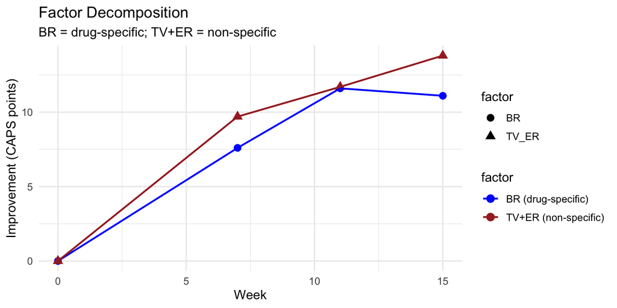

```r
factor_long <- melt(factor_data, id.vars = "week",
                    variable.name = "factor",
                    value.name = "improvement")

ggplot(factor_long, aes(x = week, y = improvement,
                        color = factor, shape = factor)) +
  geom_point(size = 3) +
  geom_line(linewidth = 0.8) +
  labs(x = "Week",
       y = "Improvement (CAPS points)",
       title = "Factor Decomposition",
       subtitle = "BR = drug-specific; TV+ER = non-specific") +
  scale_color_manual(
    values = c("BR" = "blue", "TV_ER" = "brown"),
    labels = c("BR (drug-specific)",
               "TV+ER (non-specific)")) +
  theme_minimal(base_size = 12)
```

# Fitting the Modified Gompertz

## Fit to BR (Drug-Specific Response)

```r
# Remove baseline (t=0, improvement=0) for fitting
# but it is implicitly enforced by the offset-rescaling
br_fit_data <- data.table(
  t = factor_data$week,
  y = factor_data$BR
)

# Fit using nonlinear least squares
# Start values informed by Hendrickson parameters
fit_br <- nlsLM(
  y ~ modgompertz(t, maxr, disp, rate),
  data = br_fit_data,
  start = list(maxr = 12, disp = 5, rate = 0.3),
  lower = c(maxr = 1, disp = 0.1, rate = 0.01),
  upper = c(maxr = 50, disp = 20, rate = 2)
)

cat("=== BR (Biologic Response) Gompertz Fit ===\n")
```

```
## === BR (Biologic Response) Gompertz Fit ===
```

```r
summary(fit_br)
```

```
##
## Formula: y ~ modgompertz(t, maxr, disp, rate)
##
## Parameters:
##      Estimate Std. Error t value Pr(>|t|)
## maxr  11.5791     0.8786  13.179   0.0482 *
## disp  20.0000    78.3984   0.255   0.8410
## rate   0.5565     0.5769   0.965   0.5115
## ---
## Signif. codes:  0 '***' 0.001 '**' 0.01 '*' 0.05 '.' 0.1 ' ' 1
##
## Residual standard error: 0.6788 on 1 degrees of freedom
##
## Number of iterations to convergence: 9
## Achieved convergence tolerance: 1.49e-08
```

```r
br_params <- coef(fit_br)
cat("\nFitted parameters:\n")
```

```
##
## Fitted parameters:
```

```r
cat(sprintf("  max  = %.3f\n", br_params["maxr"]))
```

```
##   max  = 11.579
```

```r
cat(sprintf("  disp = %.3f\n", br_params["disp"]))
```

```
##   disp = 20.000
```

```r
cat(sprintf("  rate = %.3f\n", br_params["rate"]))
```

```
##   rate = 0.557
```

```r
cat("\nHendrickson parameters:\n")
```

```
##
## Hendrickson parameters:
```

```r
cat("  max  = 10.986\n")
```

```
##   max  = 10.986
```

```r
cat("  disp = 5.000\n")
```

```
##   disp = 5.000
```

```r
cat("  rate = 0.420\n")
```

```
##   rate = 0.420
```

## Fit to TV+ER (Non-Specific Response)

```r
tver_fit_data <- data.table(
  t = factor_data$week,
  y = factor_data$TV_ER
)

fit_tver <- nlsLM(
  y ~ modgompertz(t, maxr, disp, rate),
  data = tver_fit_data,
  start = list(maxr = 15, disp = 5, rate = 0.3),
  lower = c(maxr = 1, disp = 0.1, rate = 0.01),
  upper = c(maxr = 50, disp = 20, rate = 2)
)

cat("=== TV+ER (Non-Specific Response) Gompertz Fit ===\n")
```

```
## === TV+ER (Non-Specific Response) Gompertz Fit ===
```

```r
summary(fit_tver)
```

```
##
## Formula: y ~ modgompertz(t, maxr, disp, rate)
##
## Parameters:
##      Estimate Std. Error t value Pr(>|t|)
## maxr  15.6711     6.3557   2.466    0.245
## disp   0.1000     5.4801   0.018    0.988
## rate   0.1375     0.3257   0.422    0.746
##
## Residual standard error: 0.4793 on 1 degrees of freedom
##
## Number of iterations to convergence: 31
## Achieved convergence tolerance: 1.49e-08
```

```r
tver_params <- coef(fit_tver)
cat("\nFitted parameters:\n")
```

```
##
## Fitted parameters:
```

```r
cat(sprintf("  max  = %.3f\n", tver_params["maxr"]))
```

```
##   max  = 15.671
```

```r
cat(sprintf("  disp = %.3f\n", tver_params["disp"]))
```

```
##   disp = 0.100
```

```r
cat(sprintf("  rate = %.3f\n", tver_params["rate"]))
```

```
##   rate = 0.137
```

```r
cat("\nHendrickson parameters (TV = ER = 'tabula rasa'):\n")
```

```
##
## Hendrickson parameters (TV = ER = 'tabula rasa'):
```

```r
cat("  max  = 6.506\n")
```

```
##   max  = 6.506
```

```r
cat("  disp = 5.000\n")
```

```
##   disp = 5.000
```

```r
cat("  rate = 0.350\n")
```

```
##   rate = 0.350
```

## Visualize the Fits

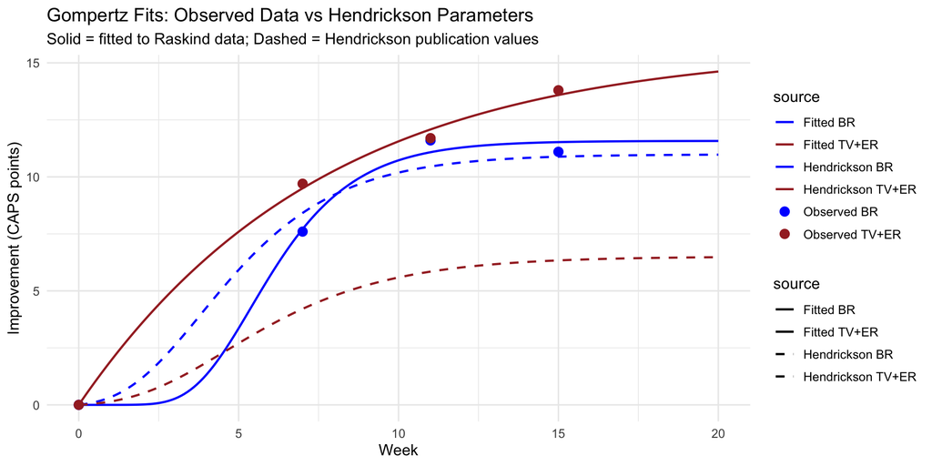

```r
t_smooth <- seq(0, 20, by = 0.1)

# Fitted curves
br_curve <- data.table(
  t = t_smooth,
  y = modgompertz(t_smooth, br_params["maxr"],
                  br_params["disp"], br_params["rate"]),
  source = "Fitted BR"
)
tver_curve <- data.table(
  t = t_smooth,
  y = modgompertz(t_smooth, tver_params["maxr"],
                  tver_params["disp"], tver_params["rate"]),
  source = "Fitted TV+ER"
)

# Hendrickson curves
br_hend <- data.table(
  t = t_smooth,
  y = modgompertz(t_smooth, 10.986, 5, 0.42),
  source = "Hendrickson BR"
)
tver_hend <- data.table(
  t = t_smooth,
  y = modgompertz(t_smooth, 6.506, 5, 0.35),
  source = "Hendrickson TV+ER"
)

curves <- rbind(br_curve, tver_curve, br_hend, tver_hend)

# Observed data points
obs <- rbind(
  data.table(t = weeks, y = factor_data$BR,
             source = "Observed BR"),
  data.table(t = weeks, y = factor_data$TV_ER,
             source = "Observed TV+ER")
)

ggplot() +
  geom_line(data = curves, aes(x = t, y = y,
            color = source, linetype = source),
            linewidth = 0.8) +
  geom_point(data = obs, aes(x = t, y = y,
             color = source), size = 3) +
  scale_color_manual(values = c(
    "Fitted BR" = "blue",
    "Hendrickson BR" = "blue",
    "Fitted TV+ER" = "brown",
    "Hendrickson TV+ER" = "brown",
    "Observed BR" = "blue",
    "Observed TV+ER" = "brown")) +
  scale_linetype_manual(values = c(
    "Fitted BR" = "solid",
    "Hendrickson BR" = "dashed",
    "Fitted TV+ER" = "solid",
    "Hendrickson TV+ER" = "dashed")) +
  labs(x = "Week",
       y = "Improvement (CAPS points)",
       title = "Gompertz Fits: Observed Data vs Hendrickson Parameters",
       subtitle = paste("Solid = fitted to Raskind data;",
                        "Dashed = Hendrickson publication values")) +
  theme_minimal(base_size = 12) +
  theme(legend.position = "right")
```

# Variance Estimation

The between-person SD of each factor is needed for the covariance matrix. Hendrickson used SD = 8 for BR and SD = 10 for TV+ER.

```r
# From Raskind Table 3:
# CAPS total score baseline SD (from 95% CI width):
# Prazosin: 77.3, 95% CI = 69.1-85.5 -> SE = 4.1, SD = 4.1*sqrt(32) = 23.2
# Placebo:  85.7, 95% CI = 78.0-93.3 -> SE = 3.9, SD = 3.9*sqrt(35) = 23.1

# Change from baseline SD:
# Difference in change: 11.3, 95% CI = 2.0-20.7
# SE of difference = (20.7-2.0)/(2*1.96) = 4.77
# Since SE = sqrt(SD_praz^2/n_praz + SD_plac^2/n_plac)
# and if SD_praz ~ SD_plac ~ SD:
# 4.77 = SD * sqrt(1/32 + 1/35) = SD * 0.247
# SD of change ~ 19.3

# The SD of 8 (BR) and 10 (TV+ER) in Hendrickson are
# lower than the raw CAPS SD because they represent the
# SD of each FACTOR, not the total outcome. The total
# outcome SD includes all three factors plus baseline
# variability.

cat("=== Variance Decomposition ===\n\n")
```

```
## === Variance Decomposition ===
```

```r
cat("Raw CAPS total score SD (from trial): ~23 points\n")
```

```
## Raw CAPS total score SD (from trial): ~23 points
```

```r
cat("This includes baseline variability + all 3 factors\n\n")
```

```
## This includes baseline variability + all 3 factors
```

```r
cat("Hendrickson factor SDs:\n")
```

```
## Hendrickson factor SDs:
```

```r
cat("  BR (drug-specific):    SD = 8\n")
```

```
##   BR (drug-specific):    SD = 8
```

```r
cat("  TV (time-variant):     SD = 10\n")
```

```
##   TV (time-variant):     SD = 10
```

```r
cat("  ER (expectancy):       SD = 10\n")
```

```
##   ER (expectancy):       SD = 10
```

```r
cat("  Baseline (BL):         SD = 18.5\n\n")
```

```
##   Baseline (BL):         SD = 18.5
```

```r
# Check: total variance at a timepoint should approximate
# the observed outcome variance
# Var(outcome) ~ Var(BL) + Var(TV) + Var(ER) + Var(BR) + cross-terms
# With autocorrelation and cross-factor correlation, the
# relationship is complex, but the marginal variances give
# an approximate bound:
total_var <- 18.5^2 + 10^2 + 10^2 + 8^2
cat(sprintf("Sum of marginal variances: %.0f\n", total_var))
```

```
## Sum of marginal variances: 606
```

```r
cat(sprintf("Implied total SD: %.1f\n", sqrt(total_var)))
```

```
## Implied total SD: 24.6
```

```r
cat("Observed CAPS SD: ~23\n")
```

```
## Observed CAPS SD: ~23
```

```r
cat("(Cross-correlations reduce the total below the sum)\n")
```

```
## (Cross-correlations reduce the total below the sum)
```

# Parameter Comparison Table

```r
comparison <- data.table(
  Factor = c("BR", "TV+ER", "TV (Hendrickson)",
             "ER (Hendrickson)"),
  max_fitted = c(br_params["maxr"], tver_params["maxr"],
                 NA, NA),
  max_hendrickson = c(10.986, NA, 6.506, 6.506),
  disp_fitted = c(br_params["disp"], tver_params["disp"],
                   NA, NA),
  disp_hendrickson = c(5, NA, 5, 5),
  rate_fitted = c(br_params["rate"], tver_params["rate"],
                   NA, NA),
  rate_hendrickson = c(0.42, NA, 0.35, 0.35),
  sd_hendrickson = c(8, NA, 10, 10)
)

cat("=== Parameter Comparison ===\n\n")
```

```
## === Parameter Comparison ===
```

```r
print(comparison, digits = 3)
```

```
##              Factor max_fitted max_hendrickson disp_fitted disp_hendrickson
##              <char>      <num>           <num>       <num>            <num>
## 1:               BR       11.6           10.99        20.0                5
## 2:            TV+ER       15.7              NA         0.1               NA
## 3: TV (Hendrickson)         NA            6.51          NA                5
## 4: ER (Hendrickson)         NA            6.51          NA                5
##    rate_fitted rate_hendrickson sd_hendrickson
##          <num>            <num>          <num>
## 1:       0.557             0.42              8
## 2:       0.137               NA             NA
## 3:          NA             0.35             10
## 4:          NA             0.35             10
```

# Discussion

## Limitations of This Reconstruction

- Only 4 timepoints are available (weeks 0, 7, 11, 15), providing limited constraint on a 3-parameter model.
- Weeks 7 and 11 values were interpolated from Figure 1D (approximate).
- The Gompertz fit is underdetermined with 4 points and 3 parameters (only 1 degree of freedom).
- The published Hendrickson parameters may have used individual-level data (available to the authors but not to us) rather than group means.

## Implications for the Simulation

The Gompertz parameters control the mean trajectory of each factor. They determine:

- **How quickly** each factor reaches its plateau (rate)
- **How large** the plateau is (max)
- **The shape** of the approach to plateau (disp)

The simulation’s power estimates are sensitive to the ratio of BR max to TV+ER max (signal-to-noise ratio) and to the rates (faster BR means more drug effect is captured within the assessment window). Figure 5 of Hendrickson et al. (2020) explores this sensitivity systematically.

```r
cat("\nSession info:\n")
```

```
##
## Session info:
```

```r
sessionInfo()$R.version$version.string
```

```
## [1] "R version 4.5.3 (2026-03-11)"
```